# Test_V2

2025-06-13

From: https://osf.io/p5xsd/files/osfstorage

New here: ds_Rothen’s includes the group as a corresponding of SynQuest in Ward.

```r
# knitr::opts_chunk$set(echo = F)
#
# load("DataSave3S_V5.RData")
```

```r
library(readr)
library(readxl)

library(tidyr)
library(dplyr)

library(papaja)

library(ggplot2)
library(ggridges)
library(ggalluvial)

library(pROC)
```

## 0.1 Load data:

In sum, I want 2 data sets: ds: item level ds_Q: ID level

```r
### 0.1.1. Ward Data

ds_syn       <- read_excel("raw_synaesthetes_consistency_anon.xlsx")
ds_syn$group <- "Syn"
ds_ctl       <- read_excel("raw_controls_consistency_anon.xlsx")
ds_ctl$group <- "Ctl"

ds_Q_syn       <- read_excel("raw_synaesthetes_questionnaire_anon.xlsx")
ds_Q_syn$group <- "Syn"
ds_Q_ctl       <- read_excel("raw_controls_questionnaire_anon.xlsx")
ds_Q_ctl$group <- "ctl"

### 0.1.1. Rothen Data

ds_Rothen <- read.csv("~/Documents/SpaceSequenceSynDiagnostic/SpaceSequenceSynDiagnostic/rawdata.txt", sep="")

### 0.1.2. Rename variables to match datasets

ds <- merge(ds_syn,ds_ctl, all = TRUE)
ds_Q <- merge(ds_Q_syn,ds_Q_ctl, all = TRUE)

sum(ds_Q$consistency_score != ds_Q$consistency) # Dubpicate variable
```

```
## [1] 0
```

```r
ds_Q$consistency <- NULL
ds_Q$...36 <- NULL
ds_Q$...37 <- NULL
ds_Q$mean_simulation_Z <- NULL
ds_Q$SD_simulation <- NULL
ds_Q$`z-score`  <- NULL

rm(ds_syn,ds_ctl,ds_Q_syn,ds_Q_ctl)

ds$ID <- ds$session_id
ds_Q$ID <- ds_Q$session_id

ds_Q$dataSource <- "Ward"
ds$dataSource <- "Ward"

# From Rothen:
names(ds_Rothen)[names(ds_Rothen) == "Group"] <- "group"
ds_Rothen$group <- as.factor(ds_Rothen$group)
levels(ds_Rothen$group) <- c("Ctl","Syn")
names(ds_Rothen)[names(ds_Rothen) == "Inducer"] <- "stimulus"
names(ds_Rothen)[names(ds_Rothen) == "X"] <- "x"
names(ds_Rothen)[names(ds_Rothen) == "Y"] <- "y"
ds_Rothen$SynQuest <- ds_Rothen$group == "Syn"

ds_Rothen$dataSource <- "Rothen"

# From the paper (all the same since lab based):
ds_Rothen$width <- 1024
ds_Rothen$height <- 768
```

```r
## 0.2 Merge data:
# Data:
ds   <- merge(ds,ds_Rothen, all = TRUE)

# Because there is no questionnaire in Nicola's data:
ds$SynQuest[ds$dataSource == "Rothen"] = "NaN"

# Questionnaire:
ID <- unique((ds_Rothen$ID))
ds_Q_Rothen <- as.data.frame(ID)
# Append rows:
ds_Q$ID <- as.character(ds_Q$ID)
ds_Q <-  bind_rows(ds_Q,ds_Q_Rothen)

# Clear up:
rm(ds_Q_Rothen, ds_Rothen)


## 0.3 Wrangle dataset

# Add Condition, i.e. stim type:
ds$Cond <- NaN
ds$Cond[ds$stimulus %in% c("1","2","3","4","5","6","7","8","9","0")] <- "number"
ds$Cond[ds$stimulus %in% c("Monday","Tuesday","Wednesday","Thursday","Friday","Saturday","Sunday")] <- "weekday"
ds$Cond[ds$stimulus %in% c("January", "February", "March", "April", "May","June","July","August","September","October","November","December")] <- "month"


# Remove if not 3 repetitions per stimuli:
ds <- ds %>%
    group_by(ID,Cond,stimulus) %>%
    mutate(Nrep = length(stimulus))

ds <- ds %>%
  filter(Nrep == 3)

# Add stimulus repetition number
ds <- ds %>%
  group_by(ID, stimulus) %>%
  arrange(ID, stimulus, .by_group = TRUE) %>%
  mutate(repetition = row_number()) %>%
  ungroup()

# Sanity Check (should be empty)
# tmp <- ds %>% filter(repetition > 3)

# Compute mean x,y:

ds <- ds %>%
  group_by(ID, Cond, stimulus) %>%
  mutate(X_mean = mean(x), Y_mean = mean(y))

# Sanity Check:
# ds %>% group_by(dataSource) %>% summarise(n = length(stimulus), maxrep = max(Nrep), minrep = min(Nrep))

## 0.4 Filter ID's
# Match ID's across datasets:
ID_ds   <- unique(ds$ID)
ID_ds_Q <- unique(ds_Q$ID)

ds <- ds %>%
    filter(ID %in% ID_ds[ID_ds %in% ID_ds_Q]) %>%
    filter(ID %in% ID_ds_Q[ID_ds_Q %in% ID_ds])

ds_Q <- ds_Q %>%
    filter(ID %in% ID_ds[ID_ds %in% ID_ds_Q]) %>%
    filter(ID %in% ID_ds_Q[ID_ds_Q %in% ID_ds])

# Sanity Check:
# sum(ID_ds == ID_ds_Q) == length(unique(ds$ID))
# sum(ID_ds == ID_ds_Q) == length(unique(ds_Q$ID))
```

```r
## 0.4 Standardize/scale coordinates

ds <- ds %>%
  group_by(ID, Cond) %>%
  mutate(x_zs = scale(x)) %>%
  mutate(y_zs = scale(y))

ds <- ds %>%
  group_by(ID, Cond, stimulus) %>%
  mutate(X_mean_zs = mean(x_zs), Y_mean_zs = mean(y_zs))
```

```r
## 0.5 Determine ID's with NaN coordinates (to exclude?)
ID_na_y <- unique(ds$ID[is.na(ds$y_zs)])
ID_na_x <- unique(ds$ID[is.na(ds$x_zs)])
```

```r
# 1. Subjective questionnaire based classification
ds_Q$QuestCriteria <- ds_Q$`questionnaire score` <= 19
sum(ds_Q$QuestCriteria)/length(ds_Q$QuestCriteria)*100
```

```
## [1] NA
```

```r
ID_SynQuest <- ds_Q$ID[ds_Q$QuestCriteria]
ds$SynQuest <- ds$ID %in% ID_SynQuest


### 1.2 Questionnaire based NR

ID_SynQuest_NR <- ds_Q %>%
  filter(`Q3 Where do you tend to routinely experience these sequences? (1= in the space outside my body; 2= on an imagined space that has no real location; 3= inside my body; 4= this doesn't apply to me!)` != 4) %>%
  filter(`Q5 Before doing this experiment, I always thought about NUMBERS as existing in a particular spatial sequence (1= strongly agree; 5= strongly disagree)` == 1) %>%
  filter(`Q6 Before doing this experiment, I always thought about DAYS OF THE WEEK as existing in a particular spatial sequence (1= strongly agree; 5= strongly disagree)` == 1) %>%
  filter(`Q7 Before doing this experiment, I always thought about MONTHS OF THE YEAR as existing in a particular spatial sequence (1= strongly agree; 5= strongly disagree)` == 1) %>%
  filter(`Q9 When doing the experiment, I didn't have any strong intuition as to where to put the NUMBERS (1= strongly agree; 5= strongly disagree)` == 5) %>%
  filter(`Q10 When doing the experiment, I didn't have any strong intuition as to where to put the DAYS OF THE WEEK (1= strongly agree; 5= strongly disagree)` == 5) %>%
  filter(`Q11 When doing the experiment, I didn't have any strong intuition as to where to put the MONTHS OF THE YEAR (1= strongly agree; 5= strongly disagree)` == 5)

ID_SynQuest_NR <- ID_SynQuest_NR$ID

ds$SynQuest_NR   <-  ds$ID %in% ID_SynQuest_NR
ds_Q$SynQuest_NR <-  ds_Q$ID %in% ID_SynQuest_NR
```

# 1. Replicated measures

## 1.1. Consistency:

Calculating consistency Each stimulus is represented by three xy coordinates - (x1, y1), (x2, y2), (x3, y3) - from the three repetitions. For each stimulus, the area of the triangle bounded by the coordinates is calculated as follows:  
$Area = (x1y2 + x2y3 + x3y1 – x1y3 – x2y1 – x3y2) / 2$

```r
# Define area calculation function
triangle_area <- function(x, y) {
  if(length(x) != 3 | length(y) != 3) return(NA)
  area <- abs(
    x[1]*y[2] + x[2]*y[3] + x[3]*y[1] -
    x[1]*y[3] - x[2]*y[1] - x[3]*y[2]
  ) / 2
  return(area)
}

# Apply per group
ds <- ds %>%
    group_by(ID, stimulus) %>%
    mutate(triangle_area = triangle_area(x, y))
```

The mean area is calculated by adding together the area for each stimulus and dividing by 29. This unit is transformed into a percentage area taking into account the different pixel resolution of each participant.  
Mean area = $(Summed area / 29) * 100 / Screen area $ Where: $Screen area = Xpixels * Ypixels$

Note: 29 since 29 stimuli

```r
# Manually adjust:

ds$height[ds$ID == 29324] <- 1080

ds$width[ds$ID == 32190 ] <- 1440

# This ID has unexpected changing screen settings, consider exclusion:
ds$width[ds$ID == 33168 ]  <- 308
ds$height[ds$ID == 33168 ] <- 149

ds$width[ds$ID == 35556 ] <- 1439
ds$height[ds$ID == 35556 ] <- 734

ds$width[ds$ID == 48114 ]  <- 1593
ds$height[ds$ID == 48114 ] <- 671

ds$width[ds$ID == 59854] <- 1366
ds$height[ds$ID == 59854] <- 663

ds$width[ds$ID == 63127] <- 1920
ds$height[ds$ID == 63127] <- 880

# Sanity Check: should be empty:
ID_heigthKO <- ds %>%
  group_by(ID) %>%
  mutate(nhig = length(unique(height))) %>%
  filter(nhig != 1) %>%
  filter(row_number()==1) %>%
  pull(ID)

ID_widthKO <- ds %>%
  group_by(ID) %>%
  mutate(nwid = length(unique(width))) %>%
  filter(nwid != 1) %>%
  filter(row_number()==1) %>%
  pull(ID)

ds$Screen_area <- ds$width*ds$height

ds <- ds %>%
  group_by(ID,repetition) %>%
  mutate(Consistency = ((sum(triangle_area)/29)*100)/Screen_area)


tmp_perID <- ds %>% ungroup() %>% group_by(ID) %>% filter(row_number() == 1) %>% select(ID, Consistency)
# names(tmp_perID) <- c("ID", "Consistency2")
ds_Q <- merge(ds_Q,tmp_perID,by = "ID")
rm(tmp_perID)

# Sanity Checks:
# Visual SC: does consitency computed here correspond to the one int he papers:
# The first is the consistency computed here, the second the one from Ward

# plot(ds_Q$Consistency,ds_Q$consistency_score)
# sum(round(ds_Q$Consistency,3) != round(ds_Q$consistency_score,3), na.rm = TRUE)
# ds_Q$ID[round(ds_Q$Consistency,3) != round(ds_Q$consistency_score,3)]
#
# # So we don't replicate the consistency from 7 ID's, 6 of them it is because we have adjusted their screen size. 39492?
# ds_Q %>% filter(ID == 39492) %>% select(Consistency, consistency_score) # Ok that is fine
```

## 1.2 Permuted consistency

*Calculating chance levels of consistency To create permuted datasets for each participant: the 87 xy coordinates are randomly shuffled so they are no longer linked to the original data labels (“Monday”, “5”, “April”, etc.). The mean area of the triangles based on the shuffled coordinates is computed (as described above), and the whole process is repeated 1000 times to obtain a subject-specific distribution of chance levels of consistency. A z-score is calculated comparing the observed consistency against the mean and SD of the permuted data:* $Z = [(observed consistency) – (mean consistency of permuted data)] / (SD of permuted data)$

## 1.3. SD as in Ward

As in Ward:

“*Specifically, the standard deviation of the x-coordinates and/or the standard deviation of the y-coordinates (measured across all trials) should exceed a proposed value of 0.075 for a normalized screen with width and height of 1 unit.*”

“*A participant who produced a horizontal straight-line form would have a very low standard deviation in the y-coordinates but a high standard deviation in x-coordinates, and a participant with a vertical line would have the reverse profile. A participant with a circular spatial form would be high on both. A participant who clicks randomly around the screen would also be high on both x and y standard deviation, but would fail the consistency tests (the triangles would be large).*”

```r
# Rescale x & y coordinates depending on screen size:
ds$xSc <- ds$x/ds$width
ds$ySc <- ds$y/ds$height

# Compute the SD across all trials (per ID):
ds <- ds %>%
  ungroup() %>%
  group_by(ID) %>%
  mutate(SD_ID_xsc = sd(xSc)) %>%
  mutate(SD_ID_ysc = sd(ySc))

ds <- ds %>%
  ungroup() %>%
  group_by(ID) %>%
  mutate(SD_ID_x = sd(x)) %>%
  mutate(SD_ID_y = sd(y))

# Add to ds_Q:
ds_Q <- merge(ds_Q, ds %>% ungroup() %>% group_by(ID) %>% filter(row_number() == 1) %>% select(ID, SD_ID_x,SD_ID_y,SD_ID_xsc,SD_ID_ysc),by = "ID")

# Sanity Check DOES NOT EXACTLY REPRODUCE!!!

# plot(ds_Q$x_sd, ds_Q$SD_ID_x)
# plot(ds_Q$x_sd, ds_Q$SD_ID_y)
# plot(ds_Q$x_sd, ds_Q$SD_ID_xsc)
# plot(ds_Q$x_sd, ds_Q$SD_ID_ysc)
#
# ds_Q$ID[round(ds_Q$x_sd,2) != round(ds_Q$SD_ID_xsc,2)]
```

# 2. New measures

These new measures aim to take advantage of several properties: - ordinality - synesthetic forms Hence we aim to take advantage of some geometrical features of the synesthetic forms. For example we can define segments across the ordered stimuli (i.e. from 1 to 9, monday to sunday and january to december).

## 2.1 Segment self-intersection

An idea I have is to look into the lines and order of the forms. I would exclude when lines crosses. (since we expect forms the lines crossing means no form is formed). Needs refinement.

```r
# Define function: this was generated by chatgpt. I tested it and it works, but need to figure out the geometry behind it:

count_self_intersections <- function(x, y, verbose = TRUE) {
  n <- length(x)
  if (n < 4) {
    if (verbose) cat("Need at least 4 points to check for self-intersection.\n")
    return(0)
  }

  # Orientation function
  orientation <- function(p, q, r) {
    val <- (q[2] - p[2]) * (r[1] - q[1]) - (q[1] - p[1]) * (r[2] - q[2])
    if (is.na(val)) return(NA)
    if (val == 0) return(0)
    if (val > 0) return(1) else return(2)
  }

  # Check if q lies on segment pr
  on_segment <- function(p, q, r) {
    if (any(is.na(c(p, q, r)))) return(FALSE)
    q[1] <= max(p[1], r[1]) && q[1] >= min(p[1], r[1]) &&
      q[2] <= max(p[2], r[2]) && q[2] >= min(p[2], r[2])
  }

  # Main intersection check
  segments_intersect <- function(p1, p2, p3, p4) {
    o1 <- orientation(p1, p2, p3)
    o2 <- orientation(p1, p2, p4)
    o3 <- orientation(p3, p4, p1)
    o4 <- orientation(p3, p4, p2)

    if (any(is.na(c(o1, o2, o3, o4)))) return(FALSE)

    # General case
    if (o1 != o2 && o3 != o4) return(TRUE)

    # Special colinear cases
    if (o1 == 0 && on_segment(p1, p3, p2)) return(TRUE)
    if (o2 == 0 && on_segment(p1, p4, p2)) return(TRUE)
    if (o3 == 0 && on_segment(p3, p1, p4)) return(TRUE)
    if (o4 == 0 && on_segment(p3, p2, p4)) return(TRUE)

    return(FALSE)
  }

  count <- 0
  for (i in 1:(n - 2)) {
    for (j in (i + 2):(n - 1)) {
      if (j == i + 1) next  # skip adjacent segments

      p1 <- c(x[i], y[i])
      p2 <- c(x[i + 1], y[i + 1])
      p3 <- c(x[j], y[j])
      p4 <- c(x[j + 1], y[j + 1])

      if (segments_intersect(p1, p2, p3, p4)) {
        count <- count + 1
        if (verbose) {
          cat(sprintf("Intersection #%d: segments (%d-%d) and (%d-%d)\n", count, i, i+1, j, j+1))
        }
      }
    }
  }

  if (verbose) cat("Total crossings:", count, "\n")
  return(count)
}
```

In each condition the connected x and y generates a segment, hence the number of segment is `length(stimuli)-1`. Moreover, currently, each stimuli is connected by 3 segment, one for each (of the 3) repetition. So dividing by 3, we have the average number of segment corssings per condition. Next we sum these for each ID Ideally we should compute the number of crossings across the repetitions, in addition to make it more complex it would also be computationally more demanding, and I don’t beleive it would lead to a significant difference.

IMPORTANT: data frame needs to be informed of stimulus order to make sense!

```r
ds <- ds %>%
  group_by(ID, Cond,repetition) %>%
  mutate(nSegments = length(stimulus)-1)

# Number of intersections for each ID X Cond X repetition
ds <- ds %>%
  group_by(stimulus) %>%
  arrange(stimulus) %>%
  arrange(ordered(stimulus, levels = c("Monday", "Tuesday", "Wednesday", "Thursday", "Friday","Saturday","Sunday"))) %>%
  arrange(ordered(stimulus, levels = c("January", "February", "March", "April", "May","June","July","August","September","October","November","December"))) %>%
  ungroup() %>%
  group_by(ID, Cond,repetition) %>%
  mutate(nLineCross = (count_self_intersections(x,y, verbose = FALSE)))

# # Linear transformation: chances for each segment to intersect:
# ds <- ds %>%
#   group_by(ID, Cond,repetition) %>%
#   mutate(mean_lineInter = nLineCross/nSegments)
#
# # Average per ID
# ds <- ds %>%
#   group_by(ID) %>%
#   mutate(GA_lineInter = mean(mean_lineInter))

# Sum per ID
# ds <- ds %>%
#   group_by(ID) %>%
#   mutate(Sum_lineInter = sum(nLineCross))

ds_sum <- ds %>%
  group_by(ID, Cond, repetition)%>%
  filter(row_number() == 1) %>%
  summarize(Sum_lineInter = sum(nLineCross), GA_lineInter = mean(nLineCross))
ds_sum2 <- ds_sum %>%
  group_by(ID) %>%
  summarise(Sum_lineInter = sum(Sum_lineInter), GA_lineInter = mean(GA_lineInter))

# Add to ds_Q
ds_Q <- merge(ds_Q, ds_sum2 %>% ungroup() %>% group_by(ID) %>% filter(row_number() == 1) %>% select(ID, Sum_lineInter, GA_lineInter),by = "ID")
```

### Example

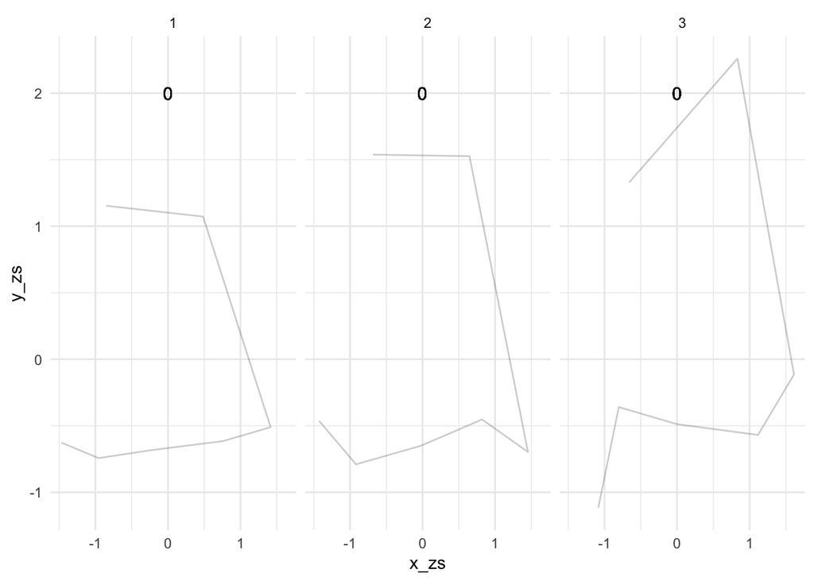

```r
IDlist = unique(ds$ID)
IDEx = sample(IDlist,1)
ds %>%
    filter(ID == IDEx) %>%
    filter(Cond == "weekday") %>%
    group_by(stimulus) %>%
    arrange(stimulus) %>%
    arrange(ordered(stimulus, levels = c("Monday", "Tuesday", "Wednesday", "Thursday", "Friday","Saturday","Sunday"))) %>%
    arrange(ordered(stimulus, levels = c("January", "February", "March", "April", "May","June","July","August","September","October","November","December"))) %>%
    ggplot(aes(x = x_zs, y = y_zs, group = stimulus, label = nLineCross, fill = stimulus)) +
    geom_path(aes(x = x_zs, y = y_zs, group = repetition), alpha = 0.2) +
    geom_text(aes(x = 0, y = 2)) +
    facet_grid(~ repetition) +
    theme_minimal()
```

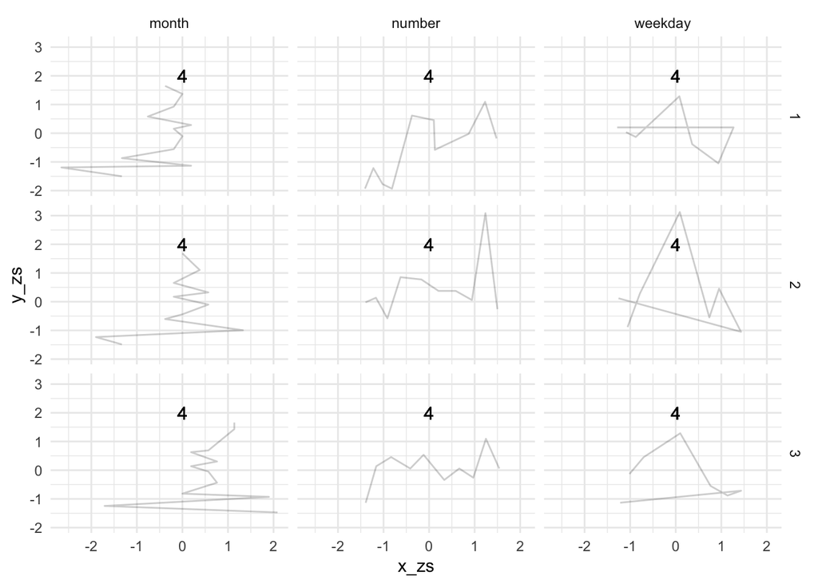

```r
IDEx = "39208"
ds %>%
    filter(ID == IDEx) %>%
    group_by(stimulus) %>%
    arrange(stimulus) %>%
    arrange(ordered(stimulus, levels = c("Monday", "Tuesday", "Wednesday", "Thursday", "Friday","Saturday","Sunday"))) %>%
    arrange(ordered(stimulus, levels = c("January", "February", "March", "April", "May","June","July","August","September","October","November","December"))) %>%
    ggplot(aes(x = x_zs, y = y_zs, group = stimulus, label = stimulus, fill = stimulus)) +
    geom_path(aes(x = x_zs, y = y_zs, group = repetition), alpha = 0.2) +
   geom_text(aes(label = unique(ds_sum2$Sum_lineInter[ds_sum2$ID == IDEx]), x = 0, y = 2)) +
    facet_grid(repetition~Cond) +
    theme_minimal()
```

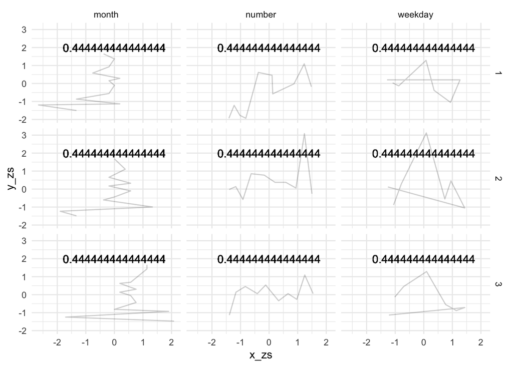

```r
ds %>%
    filter(ID == IDEx) %>%
    group_by(stimulus) %>%
    arrange(stimulus) %>%
    arrange(ordered(stimulus, levels = c("Monday", "Tuesday", "Wednesday", "Thursday", "Friday","Saturday","Sunday"))) %>%
    arrange(ordered(stimulus, levels = c("January", "February", "March", "April", "May","June","July","August","September","October","November","December"))) %>%
    ggplot(aes(x = x_zs, y = y_zs, group = stimulus, label = stimulus, fill = stimulus)) +
    geom_path(aes(x = x_zs, y = y_zs, group = repetition), alpha = 0.2) +
   geom_text(aes(label = unique(ds_sum2$GA_lineInter[ds_sum2$ID == IDEx]), x = 0, y = 2)) +
    facet_grid(repetition~Cond) +
    theme_minimal()
```

```r
IDEX = "39208"

3/(10+12+7)/3
```

```
## [1] 0.03448276
```

## 2.2. Segments (with sf)

Analyzing each repetition separately might favour horizontal positioning based on LTR order. For example, using the strategy if the number 0 is always positioned in the left, and 9 on the right (see MNL), there might be no intersections, though no Synesthesia. However it is more unlikely that this would work across repetitions (i.e. having the same vertical position). So I need to add a criteria of the number of intersections across repetitions. This would however only work if I exclude the end to 1st between each repetition.

With 3 repetitions we have: - 1 vs 2 - 2 vs 3 - 3 vs 1

We will take advantage of the `sf` package.

```r
library(sf)
# Turn off spherical geometry:
sf::sf_use_s2(FALSE)
```

```
## Spherical geometry (s2) switched off
```

```r
# Explicitly inform about item order (i.e. ordinality):
ds <- ds %>%
  group_by(Cond) %>%
  mutate(
    item_order = case_when(
      Cond == "number"  ~ match(stimulus, as.character(0:9)),
      Cond == "weekday" ~ match(stimulus, c("Monday","Tuesday","Wednesday","Thursday","Friday","Saturday","Sunday")),
      Cond == "month"   ~ match(stimulus, c("January","February","March","April","May","June", "July","August","September","October","November","December")),
      TRUE ~ NA_integer_
    )
  )%>%
  ungroup()

## Sanity Check:

# ds %>%
#     group_by(stimulus) %>%
#     filter(row_number() == 1) %>%
#     select(stimulus, item_order)

# Convert into segments with the sf package:

ds_segm <- ds %>%
  filter(!is.nan(x_zs), !is.nan(y_zs)) %>% # sf hates NaN!
  mutate(
    Group = as.character(group),
    ID     = as.character(ID),
    Cond      = as.character(Cond),
    repetition     = as.integer(repetition),
    item_order     = as.integer(item_order)
  ) %>%
  arrange(ID, Cond, repetition,Group) %>%
  group_by(ID, Cond, repetition,Group) %>%
  summarise(
    geometry = st_sfc(st_linestring(as.matrix(cbind(x_zs, y_zs)))), # preserves order
    .groups = "drop"
  ) %>%
  st_as_sf(crs = NA)
```

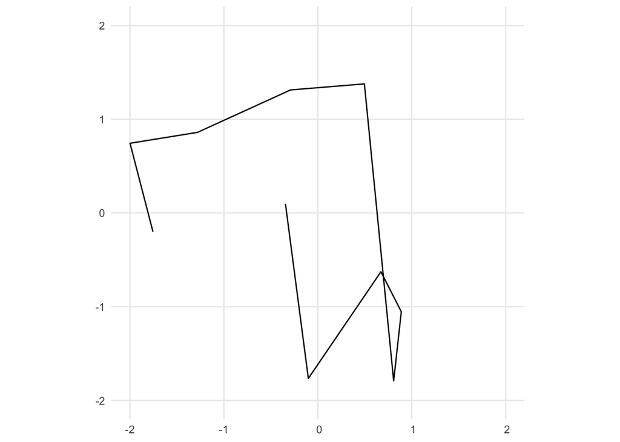

```r
# Visual Sanity Check:
# ds %>%
#   filter(ID == "44590", Cond =="number") %>%
#   group_by(stimulus) %>%
#   arrange(stimulus) %>%
#   arrange(ordered(stimulus, levels = c("Monday", "Tuesday", "Wednesday", "Thursday", "Friday","Saturday","Sunday"))) %>% arrange(ordered(stimulus, levels = c("January", "February", "March", "April", "May","June","July","August","September","October","November","December"))) %>%
#   ggplot(aes(x = x_zs, y = y_zs, group = stimulus, label = stimulus, fill = stimulus)) +
#   geom_path(aes(x = x_zs, y = y_zs, group = repetition), alpha = 0.2) +
#   xlim(-2, 2) +
#   ylim(-2,2) +
#   theme_minimal()
#
# ds_segm %>%
#   filter(ID == "44590", Cond =="number") %>%
#   ggplot() +
#   geom_sf() +
#   xlim(-2, 2) +
#   ylim(-2,2) +
#   theme_minimal()

ds_segm %>%
    filter(ID == "44590", Cond =="number", repetition == "1") %>%
    ggplot() +
    geom_sf() +
    xlim(-2, 2) +
    ylim(-2,2) +
    theme_minimal()
```

```r
tmp = ds_segm %>%
    filter(ID == "44590", Cond =="number", repetition == "1")
st_coordinates(tmp$geometry)
```

```
##                X           Y L1
##  [1,] -0.3452947  0.09697364  1
##  [2,] -0.1012382 -1.76492028  1
##  [3,]  0.6716072 -0.62709622  1
##  [4,]  0.8885463 -1.05378024  1
##  [5,]  0.8071941 -1.79077992  1
##  [6,]  0.4953442  1.37702572  1
##  [7,] -0.2910599  1.31237662  1
##  [8,] -1.2808445  0.85983296  1
##  [9,] -1.9994551  0.74346459  1
## [10,] -1.7553987 -0.20041219  1
```

```r
ds_segm %>%
    group_by(ID,Cond) %>%
    summarize(nGeom = length(geometry))
```

[output not shown]

```
## Simple feature collection with 1578 features and 3 fields (with 1 geometry empty)
## Geometry type: GEOMETRY
## Dimension:     XY
## Bounding box:  xmin: -5.833333 ymin: -5.833333 xmax: 5.833333 ymax: 5.833333
## CRS:           NA
## # A tibble: 1,578 × 4
## # Groups:   ID [535]
##    ID        Cond    nGeom                                              geometry
##    <chr>     <chr>   <int>                                     <MULTILINESTRING>
##  1 1005_SeMi month       3 ((-1.641605 -0.4667546, -1.414415 0.5049987), (-1.41…
##  2 1005_SeMi number      3 ((-0.6204158 -0.9974104, -0.5950192 0.7507642), (-0.…
##  3 1005_SeMi weekday     3 ((-0.5024139 0.2023676, -0.4165611 0.2023676, -1.204…
##  4 101_Elin  month       3 ((1.210871 -0.02886309, 1.081201 -0.3261199), (1.081…
##  5 101_Elin  weekday     3 ((-1.698763 0.3147132, -1.326374 0.7480889, -0.44238…
##  6 1025_MaJo month       3 ((-0.9358392 -1.212593, -1.451754 -0.529827, -1.5296…
##  7 1025_MaJo number      3 ((-1.797318 1.446076, -1.581875 1.199831, -1.378183 …
##  8 1025_MaJo weekday     3 ((-0.2550678 -1.256942, -0.7386338 -0.6374077, -1.38…
##  9 1027_ReEd month       3 ((0.09065595 -1.499991, -1.18641 -1.235684, -1.04451…
## 10 1027_ReEd number      3 ((2.681539 1.206992, 0.2593248 0.0324033), (0.259324…
## # ℹ 1,568 more rows
```

```r
ds_segm %>%
    group_by(ID,Cond) %>%
    summarize(nGeom = length(st_coordinates(geometry)))
```

[output not shown]

```
## Simple feature collection with 1578 features and 3 fields (with 1 geometry empty)
## Geometry type: GEOMETRY
## Dimension:     XY
## Bounding box:  xmin: -5.833333 ymin: -5.833333 xmax: 5.833333 ymax: 5.833333
## CRS:           NA
## # A tibble: 1,578 × 4
## # Groups:   ID [535]
##    ID        Cond    nGeom                                              geometry
##    <chr>     <chr>   <int>                                     <MULTILINESTRING>
##  1 1005_SeMi month     108 ((-1.641605 -0.4667546, -1.414415 0.5049987), (-1.41…
##  2 1005_SeMi number     90 ((-0.6204158 -0.9974104, -0.5950192 0.7507642), (-0.…
##  3 1005_SeMi weekday    63 ((-0.5024139 0.2023676, -0.4165611 0.2023676, -1.204…
##  4 101_Elin  month     108 ((1.210871 -0.02886309, 1.081201 -0.3261199), (1.081…
##  5 101_Elin  weekday    63 ((-1.698763 0.3147132, -1.326374 0.7480889, -0.44238…
##  6 1025_MaJo month     108 ((-0.9358392 -1.212593, -1.451754 -0.529827, -1.5296…
##  7 1025_MaJo number     90 ((-1.797318 1.446076, -1.581875 1.199831, -1.378183 …
##  8 1025_MaJo weekday    63 ((-0.2550678 -1.256942, -0.7386338 -0.6374077, -1.38…
##  9 1027_ReEd month     108 ((0.09065595 -1.499991, -1.18641 -1.235684, -1.04451…
## 10 1027_ReEd number     90 ((2.681539 1.206992, 0.2593248 0.0324033), (0.259324…
## # ℹ 1,568 more rows
```

```r
# Somethning is off:
10*3
```

```
## [1] 30
```

```r
7*(7+2)
```

```
## [1] 63
```

```r
12*(12+2)
```

```
## [1] 168
```

## 2.3. Between repetitions:

```r
# Oh Gosh, loop it:
ID_list     <- unique(ds$ID)
Cond_list   <- unique(ds$Cond)
ds$BtwInter <- NaN

for (ID_n in 1:length(ID_list)) {
   for (Cond_n in 1: length(Cond_list)) {
     ds_here = ds_segm %>% filter(ID == ID_list[ID_n]) %>% filter(Cond == Cond_list[Cond_n])
     if (length(ds_here$geometry) != 3) {
       break
     }

     #  N_inter = InterBtwRep(ds_here$geometry[1],ds_here$geometry[2],ds_here$geometry[3])
     # ds[ds$ID == ID_list[ID_n] & ds$Cond == Cond_list[Cond_n],]$BtwInter = N_inter

     segm1 = ds_here$geometry[1]
     segm2 = ds_here$geometry[2]
     segm3 = ds_here$geometry[3]

     i12 <- st_intersection(segm1,segm2)
     i13 <- st_intersection(segm1,segm3)
     i23 <- st_intersection(segm2,segm3)

     i12 <- st_cast(i12, "POINT")
     i13 <- st_cast(i13, "POINT")
     i23 <- st_cast(i23, "POINT")

     # # Sometimes the intersections are plain lines:
     # if (st_geometry_type(i12) == "GEOMETRYCOLLECTION") {
     #   i12 <- st_collection_extract(i12, type = "POINT")
     #
     # } else if (st_geometry_type(i12) == "MULTILINESTRING"){
     #   i12 <- NULL
     # }
     #
     # if (st_geometry_type(i13) == "GEOMETRYCOLLECTION") {
     #   i13 <- st_collection_extract(i13, type = "POINT")
     # }
     # if (st_geometry_type(i23) == "GEOMETRYCOLLECTION") {
     #   i23 <- st_collection_extract(i23, type = "POINT")
     # }

     # plot(segm1)
     # plot(segm2, add = TRUE)
     # plot(segm3, add = TRUE)
     # plot(i12, add = TRUE)
     # plot(i13, add = TRUE)
     # plot(i23, add = TRUE)

     nInter = nrow(st_coordinates(i12)) + nrow(st_coordinates(i13)) + nrow(st_coordinates(i23))

     ds[ds$ID == ID_list[ID_n] & ds$Cond == Cond_list[Cond_n],]$BtwInter = nInter

   }
}

# Average per ID
ds <- ds %>%
  group_by(ID) %>%
  mutate(GA_BtwInter = mean(BtwInter, na.rm = TRUE))


ds_Q <- merge(ds_Q, ds %>% ungroup() %>% group_by(ID) %>% filter(row_number() == 1) %>% select(ID, GA_BtwInter),by = "ID")
```

## 2.4. Segment length

```r
ds_segm$leng <- st_length(ds_segm)

ds_segm <- ds_segm %>%
  group_by(ID) %>%
  mutate(GA_segm = mean(leng, na.rm = TRUE))

ds_Q <- merge(ds_Q, ds_segm %>% ungroup() %>% group_by(ID) %>% filter(row_number() == 1) %>% select(ID, GA_segm),by = "ID")
```

## 2.5. Distances between repetitions

```r
ID_list     <- unique(ds$ID)
Cond_list   <- unique(ds$Cond)
ds$BtwDist <- NaN

for (ID_n in 1:length(ID_list)) {
   for (Cond_n in 1: length(Cond_list)) {
     ds_here = ds_segm %>% filter(ID == ID_list[ID_n]) %>% filter(Cond == Cond_list[Cond_n])
     if (length(ds_here$geometry) != 3) {
       break
     }

     ds[ds$ID == ID_list[ID_n] & ds$Cond == Cond_list[Cond_n],]$BtwDist = mean(st_distance(ds_here))

   }
}


# Average per ID
ds <- ds %>%
  group_by(ID) %>%
  mutate(GA_BtwDist = mean(BtwDist, na.rm = TRUE))


ds_Q <- merge(ds_Q, ds %>% ungroup() %>% group_by(ID) %>% filter(row_number() == 1) %>% select(ID, GA_BtwDist),by = "ID")
```

# 3. Polygon based geometries

## 3.1. Polygon area

```r
ds_poly          <- st_cast(ds_segm, "POLYGON")
ds_poly$area     <- st_area(ds_poly)

ds_poly <- ds_poly %>%
  group_by(ID) %>%
  mutate(GA_areaPoly = mean(area, na.rm = TRUE))

ds_Q <- merge(ds_Q, ds_poly %>% ungroup() %>% group_by(ID) %>% filter(row_number() == 1) %>% select(ID, GA_areaPoly),by = "ID")
```

## 3.1. Polygon simplicity

```r
ds_poly$isSimple <- st_is_simple(ds_poly)

ds_poly <- ds_poly %>%
  group_by(ID) %>%
  mutate(GA_isSimple = mean(isSimple, na.rm = TRUE))

ds_Q <- merge(ds_Q, ds_poly %>% ungroup() %>% group_by(ID) %>% filter(row_number() == 1) %>% select(ID, GA_isSimple),by = "ID")
```

## 3.2. Topological validity

is topologically valid:

```r
ds_poly$isValid <- st_is_valid(ds_poly)

ds_poly <- ds_poly %>%
  group_by(ID) %>%
  mutate(Sum_isValid = sum(isValid, na.rm = TRUE))

ds_Q <- merge(ds_Q, ds_poly %>% ungroup() %>% group_by(ID) %>% filter(row_number() == 1) %>% select(ID, Sum_isValid),by = "ID")
```

## 3.3 is clockwise (?)

```r
ds_poly$isClockwise <- lwgeom::st_is_polygon_cw(ds_poly)

ds_poly <- ds_poly %>%
  group_by(ID) %>%
  mutate(Sum_isClockwise= sum(isClockwise, na.rm = TRUE))

ds_Q <- merge(ds_Q, ds_poly %>% ungroup() %>% group_by(ID) %>% filter(row_number() == 1) %>% select(ID, Sum_isClockwise),by = "ID")
```

## 3.4. Convex hull area

```r
ds_conv_hull <- ds_segm %>%
  mutate(geometry = st_convex_hull(geometry))
ds_conv_hull$area_convhull <- st_area(ds_conv_hull)

ds_conv_hull <- ds_conv_hull %>%
  group_by(ID) %>%
  mutate(GA_area_convhull = mean(area_convhull, na.rm = TRUE))


ds_Q <- merge(ds_Q, ds_conv_hull %>% ungroup() %>% group_by(ID) %>% filter(row_number() == 1) %>% select(ID, GA_area_convhull),by = "ID")
```

# 4. AUC

## 4.1. Consistency:

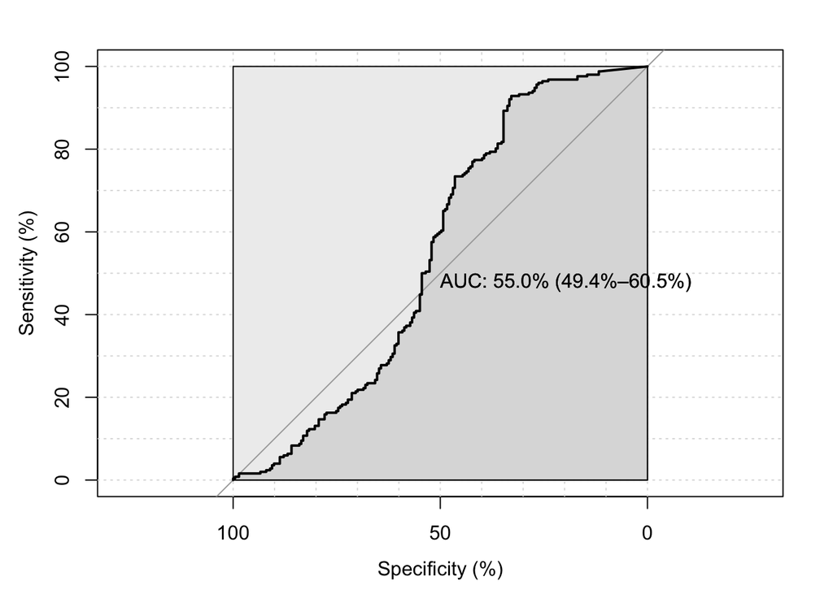

```r
roc_line <- roc(group ~ Consistency, ds_Q,
                percent=TRUE,
                # arguments for ci
                ci=TRUE, boot.n=100, ci.alpha=0.9, stratified=FALSE,
                # arguments for plot
                plot=TRUE, auc.polygon=TRUE, max.auc.polygon=TRUE, grid=TRUE,
                print.auc=TRUE, show.thres=TRUE)
```

```r
# Best threshold using Youden's J
best_coords <- coords(roc_line, "best", ret = c("threshold", "sensitivity", "specificity"), best.method = "youden")
knitr::kable(best_coords)
```

| threshold | sensitivity | specificity |
| --- | --- | --- |
| 0.0219735 | 92.85714 | 32.86385 |

## 4.2. Line inter:

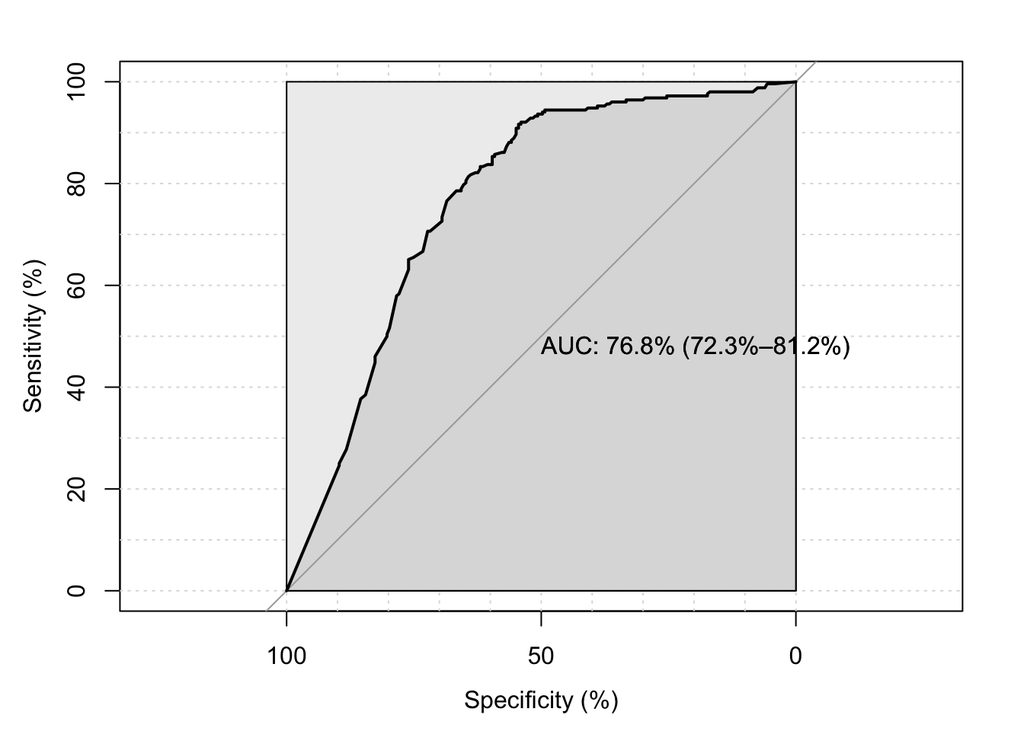

```r
roc_line <- roc(group ~ GA_lineInter , ds_Q,
                percent=TRUE,
                # arguments for ci
                ci=TRUE, boot.n=100, ci.alpha=0.9, stratified=FALSE,
                # arguments for plot
                plot=TRUE, auc.polygon=TRUE, max.auc.polygon=TRUE, grid=TRUE,
                print.auc=TRUE, show.thres=TRUE)
```

```r
# Best threshold using Youden's J
best_coords <- coords(roc_line, "best", ret = c("threshold", "sensitivity", "specificity"), best.method = "youden")
knitr::kable(best_coords)
```

| threshold | sensitivity | specificity |
| --- | --- | --- |
| 4.833333 | 91.66667 | 54.46009 |

Sum

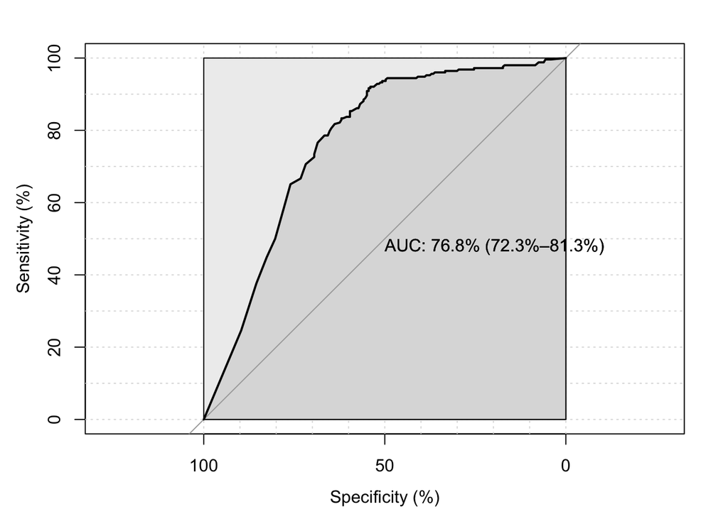

```r
roc_line <- roc(group ~ Sum_lineInter , ds_Q,
                percent=TRUE,
                # arguments for ci
                ci=TRUE, boot.n=100, ci.alpha=0.9, stratified=FALSE,
                # arguments for plot
                plot=TRUE, auc.polygon=TRUE, max.auc.polygon=TRUE, grid=TRUE,
                print.auc=TRUE, show.thres=TRUE)
```

```r
# Best threshold using Youden's J
best_coords <- coords(roc_line, "best", ret = c("threshold", "sensitivity", "specificity"), best.method = "youden")
knitr::kable(best_coords)
```

| threshold | sensitivity | specificity |
| --- | --- | --- |
| 43.5 | 91.66667 | 54.46009 |

## 4.3. Line between

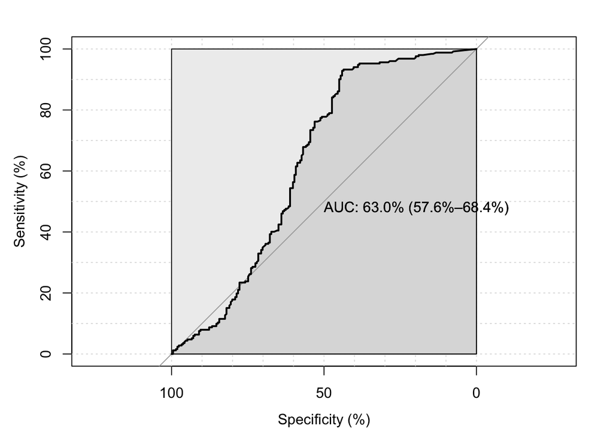

```r
roc_line <- roc(group ~ GA_BtwInter , ds_Q,
                percent=TRUE,
                # arguments for ci
                ci=TRUE, boot.n=100, ci.alpha=0.9, stratified=FALSE,
                # arguments for plot
                plot=TRUE, auc.polygon=TRUE, max.auc.polygon=TRUE, grid=TRUE,
                print.auc=TRUE, show.thres=TRUE)
```

```r
# Best threshold using Youden's J
best_coords <- coords(roc_line, "best", ret = c("threshold", "sensitivity", "specificity"), best.method = "youden")
knitr::kable(best_coords)
```

| threshold | sensitivity | specificity |
| --- | --- | --- |
| 6.172414 | 92.85714 | 44.07583 |

## 4.4. Line length

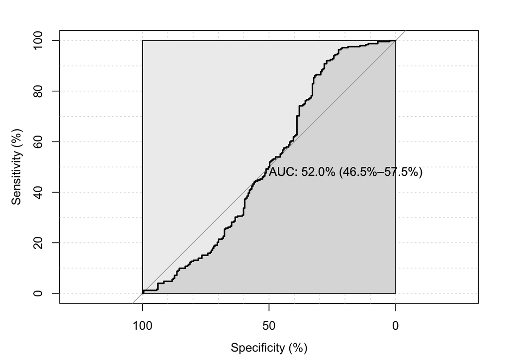

```r
roc_line <- roc(group ~ GA_segm , ds_Q,
                percent=TRUE,
                # arguments for ci
                ci=TRUE, boot.n=100, ci.alpha=0.9, stratified=FALSE,
                # arguments for plot
                plot=TRUE, auc.polygon=TRUE, max.auc.polygon=TRUE, grid=TRUE,
                print.auc=TRUE, show.thres=TRUE)
```

```r
# Best threshold using Youden's J
best_coords <- coords(roc_line, "best", ret = c("threshold", "sensitivity", "specificity"), best.method = "youden")
knitr::kable(best_coords)
```

| threshold | sensitivity | specificity |
| --- | --- | --- |
| 6.556325 | 92.06349 | 27.23005 |

## 4.5. Poly area

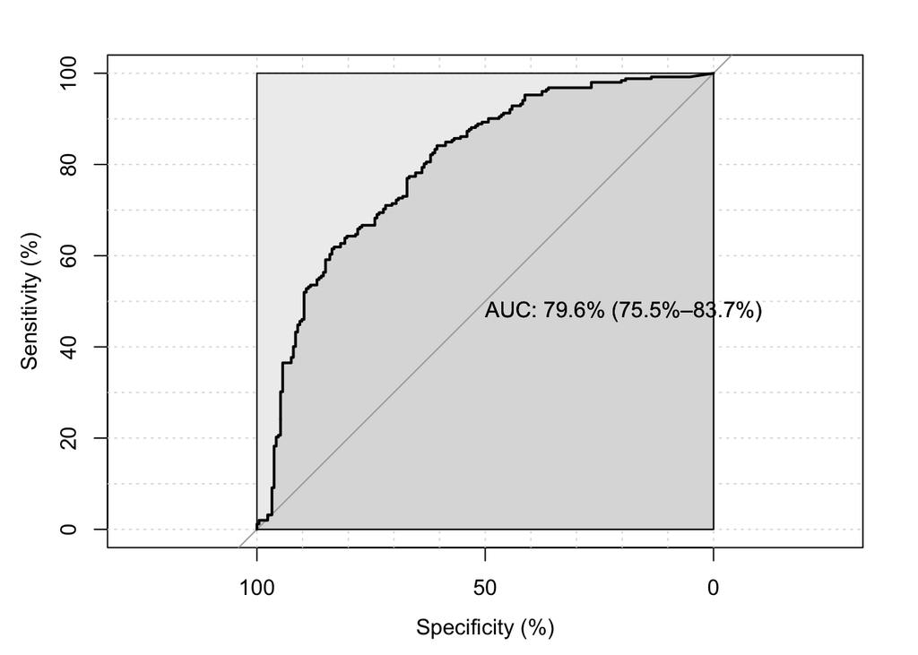

```r
roc_line <- roc(group ~ GA_areaPoly , ds_Q,
                percent=TRUE,
                # arguments for ci
                ci=TRUE, boot.n=100, ci.alpha=0.9, stratified=FALSE,
                # arguments for plot
                plot=TRUE, auc.polygon=TRUE, max.auc.polygon=TRUE, grid=TRUE,
                print.auc=TRUE, show.thres=TRUE)
```

```r
# Best threshold using Youden's J
best_coords <- coords(roc_line, "best", ret = c("threshold", "sensitivity", "specificity"), best.method = "youden")
knitr::kable(best_coords)
```

| threshold | sensitivity | specificity |
| --- | --- | --- |
| 2.066417 | 61.50794 | 83.56808 |

## 4.6. Poly Simple

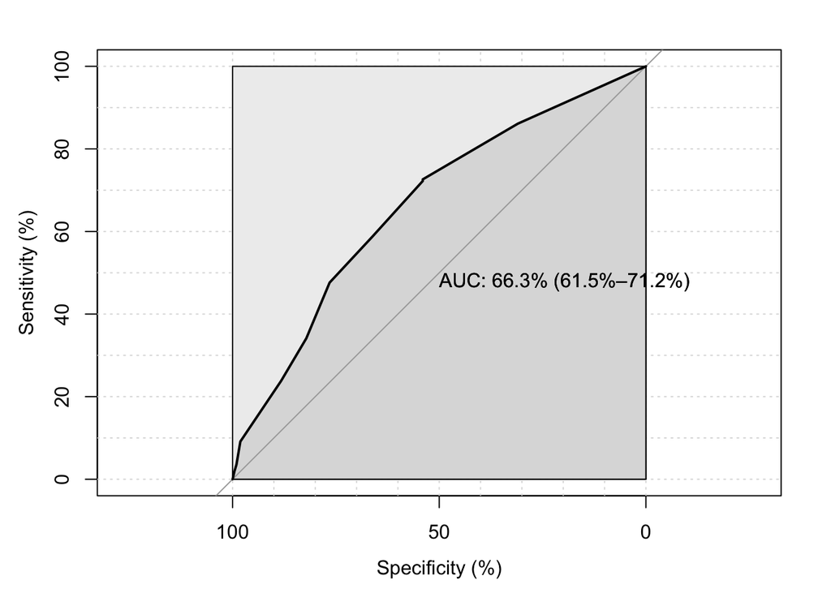

```r
roc_line <- roc(group ~ GA_isSimple , ds_Q,
                percent=TRUE,
                # arguments for ci
                ci=TRUE, boot.n=100, ci.alpha=0.9, stratified=FALSE,
                # arguments for plot
                plot=TRUE, auc.polygon=TRUE, max.auc.polygon=TRUE, grid=TRUE,
                print.auc=TRUE, show.thres=TRUE)
```

```r
# Best threshold using Youden's J
best_coords <- coords(roc_line, "best", ret = c("threshold", "sensitivity", "specificity"), best.method = "youden")
knitr::kable(best_coords)
```

| threshold | sensitivity | specificity |
| --- | --- | --- |
| 0.1388889 | 72.61905 | 53.99061 |

## 4.7. Poly Valid

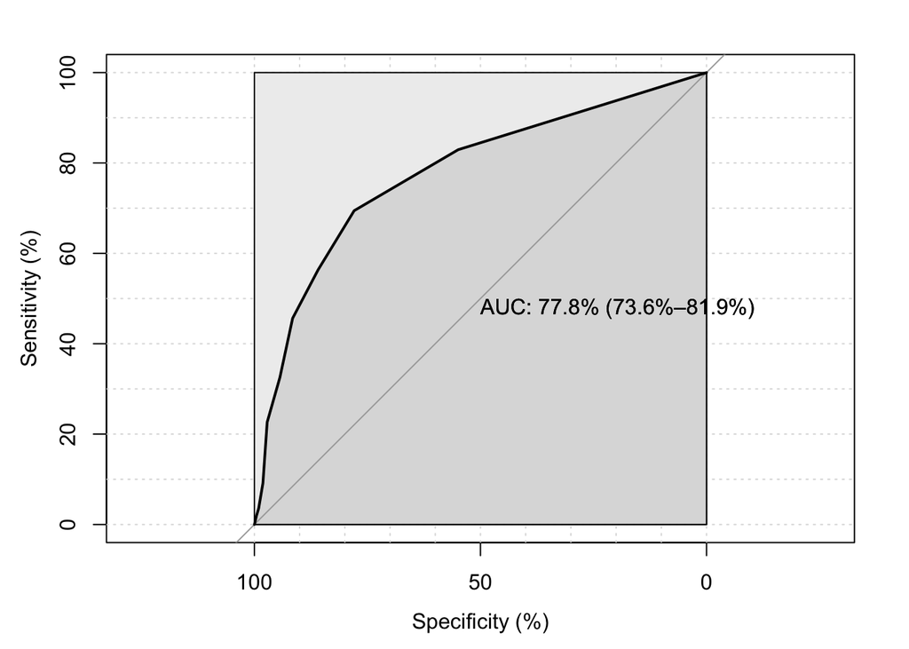

```r
roc_line <- roc(group ~ Sum_isValid , ds_Q,
                percent=TRUE,
                # arguments for ci
                ci=TRUE, boot.n=100, ci.alpha=0.9, stratified=FALSE,
                # arguments for plot
                plot=TRUE, auc.polygon=TRUE, max.auc.polygon=TRUE, grid=TRUE,
                print.auc=TRUE, show.thres=TRUE)
```

```r
# Best threshold using Youden's J
best_coords <- coords(roc_line, "best", ret = c("threshold", "sensitivity", "specificity"), best.method = "youden")
knitr::kable(best_coords)
```

| threshold | sensitivity | specificity |
| --- | --- | --- |
| 1.5 | 69.44444 | 77.93427 |

## 4.8. Poly Clockwise

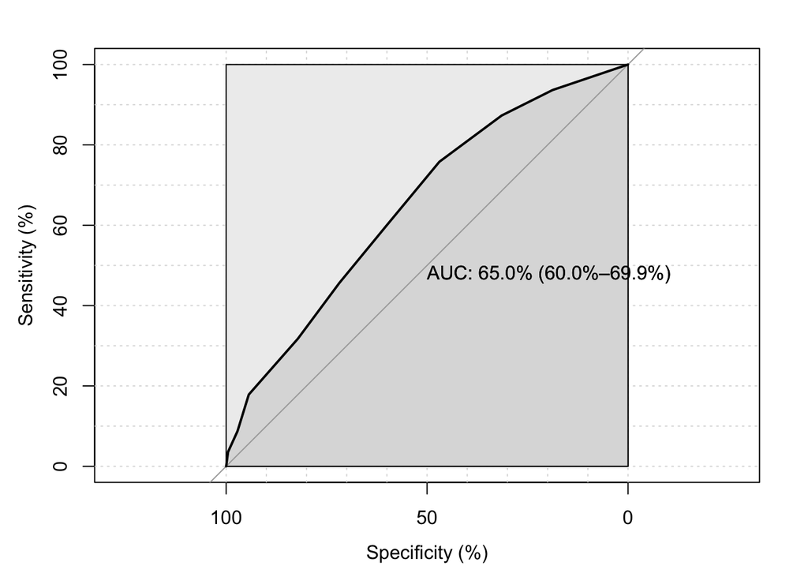

```r
roc_line <- roc(group ~ Sum_isClockwise , ds_Q,
                percent=TRUE,
                # arguments for ci
                ci=TRUE, boot.n=100, ci.alpha=0.9, stratified=FALSE,
                # arguments for plot
                plot=TRUE, auc.polygon=TRUE, max.auc.polygon=TRUE, grid=TRUE,
                print.auc=TRUE, show.thres=TRUE)
```

```r
# Best threshold using Youden's J
best_coords <- coords(roc_line, "best", ret = c("threshold", "sensitivity", "specificity"), best.method = "youden")
knitr::kable(best_coords)
```

| threshold | sensitivity | specificity |
| --- | --- | --- |
| 2.5 | 75.79365 | 46.94836 |

## 4.7. Convex hull area

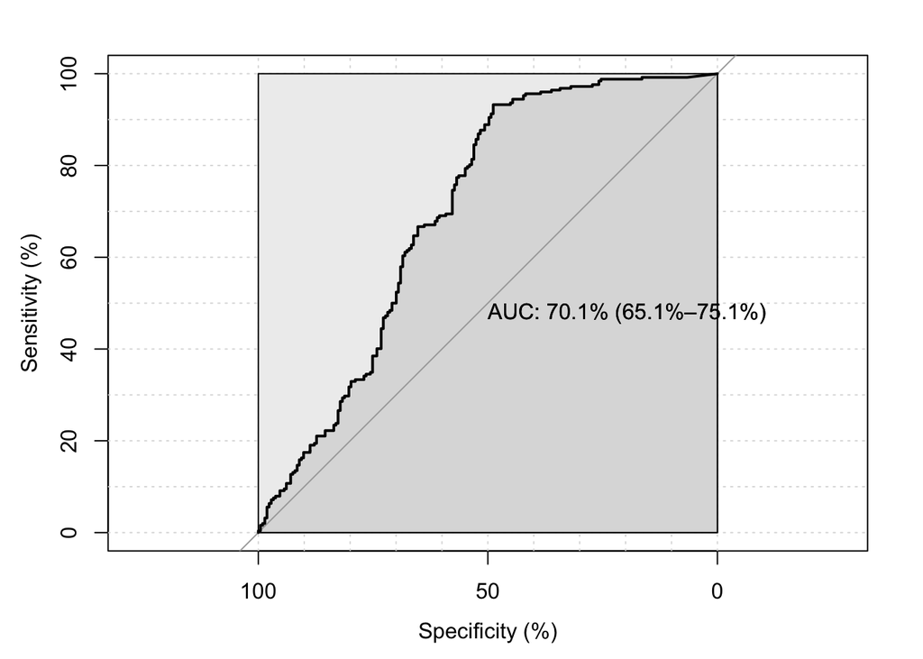

```r
roc_line <- roc(group ~ GA_area_convhull , ds_Q,
                percent=TRUE,
                # arguments for ci
                ci=TRUE, boot.n=100, ci.alpha=0.9, stratified=FALSE,
                # arguments for plot
                plot=TRUE, auc.polygon=TRUE, max.auc.polygon=TRUE, grid=TRUE,
                print.auc=TRUE, show.thres=TRUE)
```

```r
# Best threshold using Youden's J
best_coords <- coords(roc_line, "best", ret = c("threshold", "sensitivity", "specificity"), best.method = "youden")
knitr::kable(best_coords)
```

| threshold | sensitivity | specificity |
| --- | --- | --- |
| 2.361803 | 93.25397 | 48.82629 |